# EDA Final project

mroe1

28/05/2020

# 2 Exploratory data analysis

In this project, I inversitgated over 150 river stations in europe, and issuses relating to changes in seasonal discharge, particularly if changes in mean runoff have taken place over the last 40 years

## 2.1 analysis of stations

### 2.1.1 station location

stations are located in europe, with particularly density of location in mainland western europe and scandinavia, there are some stations sparely distributed in Russia and eastern europe, and the British Isles and Iceland.

[interactive chart not shown]

### 2.1.2 number of stations per country/river and number of stations per river

number of stations per country

| Country | N |
| --- | --- |
| FR | 2 |
| CZ | 5 |
| SK | 2 |
| SE | 27 |
| DE | 78 |
| IS | 1 |
| NL | 3 |
| HU | 1 |
| PL | 1 |
| RS | 2 |
| GB | 5 |
| NO | 26 |
| RO | 3 |
| FI | 16 |
| DK | 5 |
| CH | 22 |
| RU | 7 |
| LT | 1 |
| UA | 1 |

number of rivers per country

| Country | N |
| --- | --- |
| FR | 1 |
| CZ | 4 |
| SK | 2 |
| SE | 26 |
| DE | 54 |
| IS | 1 |
| NL | 2 |
| HU | 1 |
| PL | 1 |
| RS | 2 |
| GB | 4 |
| NO | 23 |
| RO | 2 |
| FI | 10 |
| DK | 5 |
| CH | 16 |
| RU | 7 |
| LT | 1 |
| UA | 1 |

number of stations per river

| River | N |
| --- | --- |
| LOIRE | 2 |
| ELBE RIVER | 5 |
| DIVOKA ORLICE | 1 |
| MORAVA | 2 |
| DANUBE RIVER | 13 |
| VAH | 1 |
| ODER RIVER | 3 |
| ENNINGDALSAELVEN | 1 |
| GOETA AELV | 1 |
| TORNETRAESK | 1 |
| VISKAN | 1 |
| FYLLEAN | 1 |
| LAGAN (SWEDEN) | 1 |
| GROETSJOEN | 1 |
| VAESTERDALAELVEN | 1 |
| TAENNAN | 2 |
| LJUSNAN | 1 |
| HELGE A | 1 |
| ALSTERAN | 1 |
| SOLGENAN | 1 |
| FYRSJOEN | 1 |
| MAELAREN | 1 |
| NYKOEPINGSAN | 1 |
| MEDSTUGUAN | 1 |
| UMEAELVEN | 1 |
| TAERNAAN | 1 |
| VATTHOLMAAN | 1 |
| VINDELAELVEN | 1 |
| PITEAELVEN | 1 |
| LULEAELVEN | 1 |

[output cut: 123 more lines]

### 2.1.3 Distribution in space of stations

There is a large cluster of stations around 45-50 degrees in latitude and 5 to 15 degrees in longitude, these stations would correspond to rivers mainly flowing out of alpine regions in Switzerland and Germany.

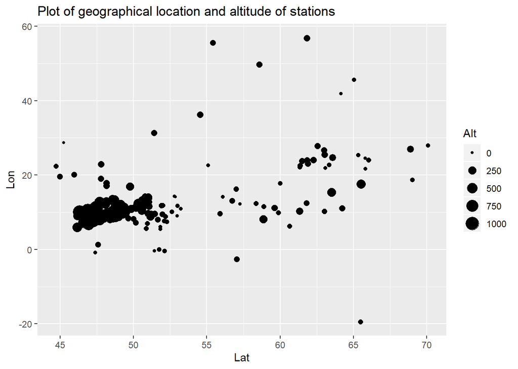

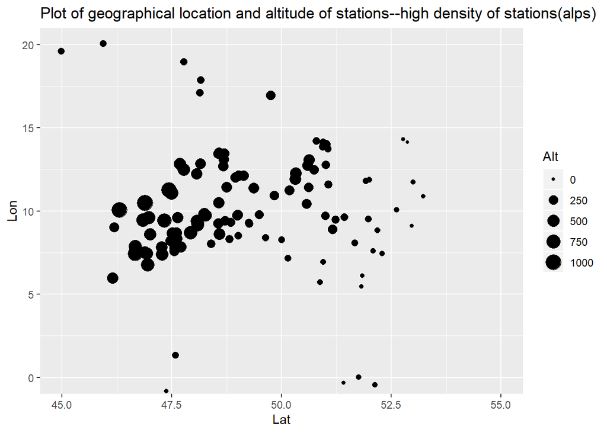

### 2.1.4 distribution by number of years of recorded data

while this is from information given, the actual raw dataset may differ.

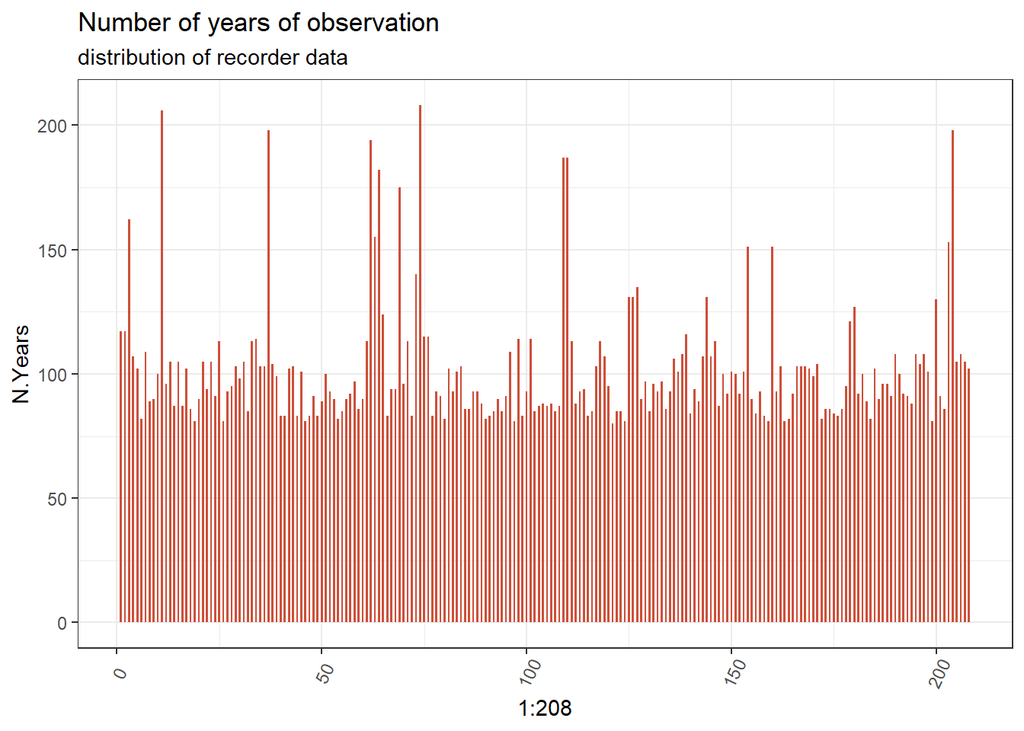

## 2.2 annual and seasonal runoff

### 2.2.2 catergorisation of the data

After calculating the minimum and maximum run off for each year for each station, I plotted the maximum value and minimum value and made categories for the data. I also categorised by altitude, though some records were missing.

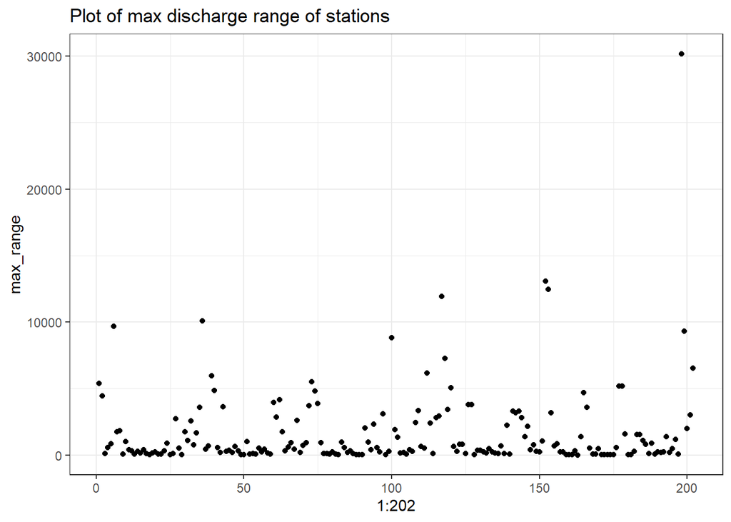

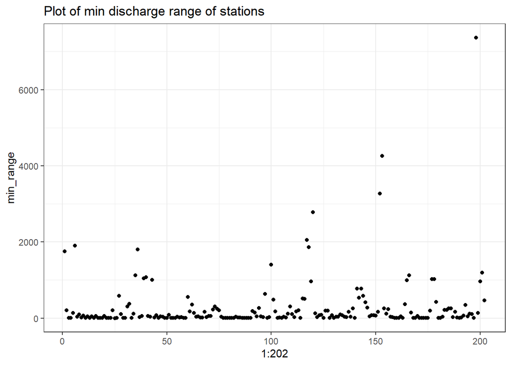

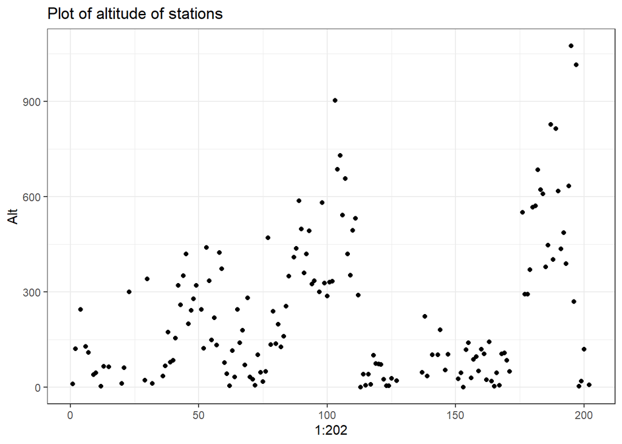

### 2.2.3 percantage change in ratio

calculating the mean of the ratios of max/mean and min/mean, for the period before 1980 and after 1980, then calculating the difference between values shows changes in runoff post 1980 relative to pre 1980

class of each station

| ID | max_range_class | min_range_class | alt_range_class | meanmax_difference | meanmin_difference |
| --- | --- | --- | --- | --- | --- |
| 6140400 | medium | low | low | 0.0264898 | 0.0264898 |
| 6140700 | low | low | NA | 0.0223525 | 0.0223525 |
| 6142100 | low | low | medium | -0.0106945 | -0.0106945 |
| 6142120 | low | low | NA | 0.0044255 | 0.0044255 |
| 6142200 | high | high | low | -0.0089567 | -0.0089567 |
| 6142620 | low | low | low | -0.0063470 | -0.0063470 |
| 6157100 | low | low | NA | 0.0110078 | 0.0110078 |
| 6229100 | low | low | low | 0.0067950 | 0.0067950 |
| 6229500 | low | low | low | -0.1639984 | -0.1639984 |
| 6232101 | low | low | NA | 0.0245890 | 0.0245890 |
| 6233100 | low | low | low | 0.0374359 | 0.0374359 |
| 6233150 | low | low | low | 0.0370669 | 0.0370669 |
| 6233170 | low | low | NA | -0.0161301 | -0.0161301 |
| 6233200 | low | low | low | 0.0091541 | 0.0091541 |
| 6233205 | low | low | NA | 0.0253042 | 0.0253042 |
| 6233220 | low | low | NA | 0.0146833 | 0.0146833 |
| 6233222 | low | low | NA | -0.0003557 | -0.0003557 |
| 6233227 | low | low | NA | 0.0154530 | 0.0154530 |
| 6233250 | low | low | low | 0.0371142 | 0.0371142 |
| 6233350 | low | low | low | 0.0575531 | 0.0575531 |
| 6233366 | low | low | NA | 0.0187242 | 0.0187242 |
| 6233400 | low | low | medium | 0.0011682 | 0.0011682 |
| 6233410 | low | low | NA | -0.0875707 | -0.0875707 |
| 6233440 | low | low | NA | 0.0152494 | 0.0152494 |
| 6233465 | low | low | NA | -0.0089577 | -0.0089577 |
| 6233502 | medium | medium | NA | 0.0719618 | 0.0719618 |
| 6233520 | low | low | NA | 0.0087526 | 0.0087526 |
| 6233600 | low | low | low | 0.0435289 | 0.0435289 |
| 6233680 | low | low | medium | 0.0256148 | 0.0256148 |
| 6233710 | low | low | NA | 0.0283054 | 0.0283054 |

[output cut: 170 more lines]

### 2.2.4 aggregation of daily runnoff by season

calculating changes in runoff on a seasonal basis, looking at summer and winter runoff

investigating changes in seasonal runnoff pre and post 1980

| id | season | year_class | V1 |
| --- | --- | --- | --- |
| 6140400 | winter | Pre 1980 | 412.1500843 |
| 6140400 | winter | Post 1980 | 445.6715100 |
| 6140700 | winter | Pre 1980 | 4.1455677 |
| 6140700 | winter | Post 1980 | 5.1399858 |
| 6142100 | winter | Pre 1980 | 22.1077073 |
| 6142100 | winter | Post 1980 | 22.2365305 |
| 6142120 | winter | Pre 1980 | 79.5653505 |
| 6142120 | winter | Post 1980 | 82.3952390 |
| 6142200 | winter | Pre 1980 | 1727.8781035 |
| 6142200 | winter | Post 1980 | 1949.3895894 |
| 6142620 | winter | Pre 1980 | 150.4210744 |
| 6142620 | winter | Post 1980 | 167.1850118 |
| 6157100 | winter | Pre 1980 | 49.5773500 |
| 6157100 | winter | Post 1980 | 47.4534853 |
| 6229100 | winter | Pre 1980 | 11.5113751 |
| 6229100 | winter | Post 1980 | 15.7393362 |
| 6229500 | winter | Pre 1980 | 548.5214389 |
| 6229500 | winter | Post 1980 | 698.0949668 |
| 6232101 | winter | Pre 1980 | 18.1640393 |
| 6232101 | winter | Post 1980 | 20.3075558 |
| 6233100 | winter | Pre 1980 | 42.2232480 |
| 6233100 | winter | Post 1980 | 59.7469532 |
| 6233150 | winter | Pre 1980 | 6.0730087 |
| 6233150 | winter | Post 1980 | 8.5528660 |
| 6233170 | winter | Pre 1980 | 75.6720595 |
| 6233170 | winter | Post 1980 | 97.9167665 |
| 6233200 | winter | Pre 1980 | 3.0350309 |
| 6233200 | winter | Post 1980 | 2.7620891 |
| 6233205 | winter | Pre 1980 | 6.7974417 |
| 6233205 | winter | Post 1980 | 9.4171835 |

[output cut: 770 more lines]

### 2.2.5 percentage change

plotting reulsts, in winter, runnoff has increased over the period 1980-present, this relationship is unclear in the summer period with different rivers showing falls and rises, further investigations would be needed to indentify why this result exists

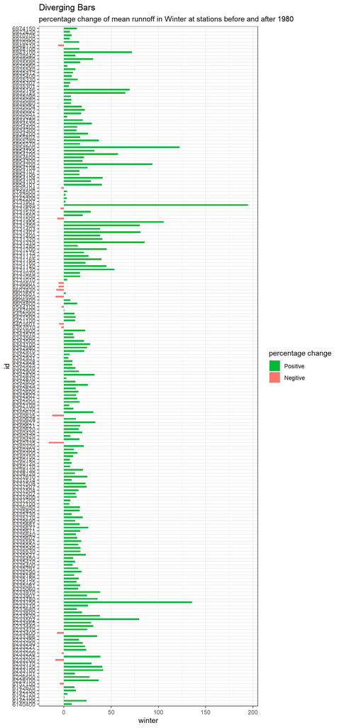

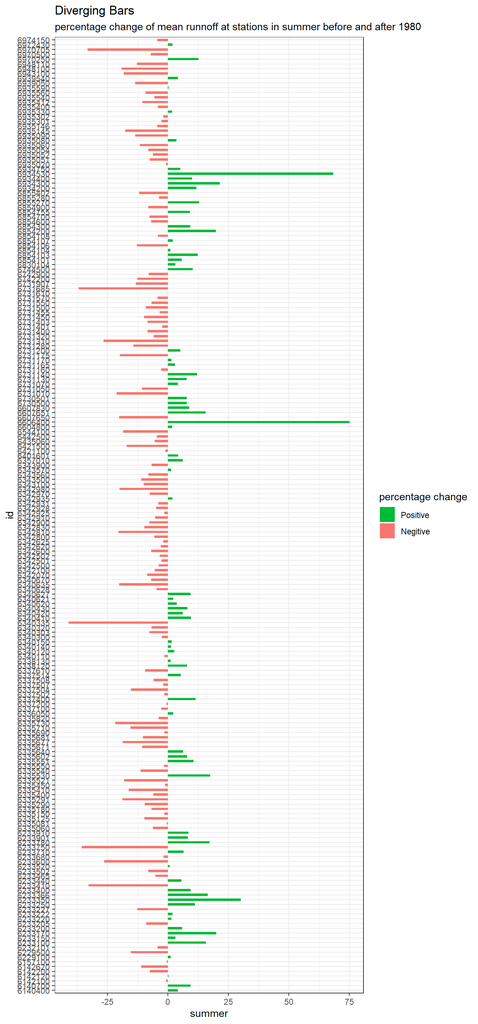

## 2.3 Five chsoen rivers

### 2.3.1 Five rivers

Danube river-bratislava, while there are no dams between Vienna and Bratislava, the danube has many dams in its upper channel and just past the station there is a dam, there has been lots of conflict between Slovakia and hungary on wheter further interventions should take place

I chose stations based on large mean values, large standard deviations, large altitude, high latitude, and high max values, were duplicate rivers were chosen, another station which a smaller value was chosen

chosen stations

| ID | Station | River | Country | Continent | Lat | Lon | Alt | N.Years |
| --- | --- | --- | --- | --- | --- | --- | --- | --- |
| 6142200 | BRATISLAVA | DANUBE RIVER | SK | EU | 48.14 | 17.109600 | 128 | 109 |
| 6335060 | KOELN | RHINE RIVER | DE | EU | 50.94 | 6.963293 | 34 | 198 |
| 6731400 | LANGNES | GLAMA | NO | EU | 59.61 | 11.118062 | 101 | 107 |
| 6935412 | APPENZELL | SITTER | CH | EU | 47.33 | 9.410600 | 815 | 100 |
| 6939540 | GSTEIG | LUETSCHINE | CH | EU | 46.66 | 7.871500 | 634 | 104 |

### 2.3.2 Seasonal runnoff at monthly scale

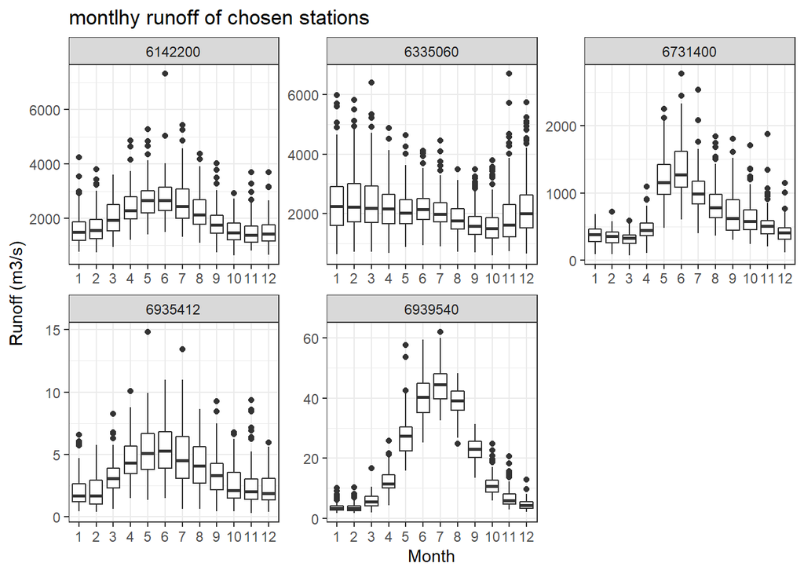

### 2.3.3 correlation matrix

glama river is highly uncorrelated with the other rivers.

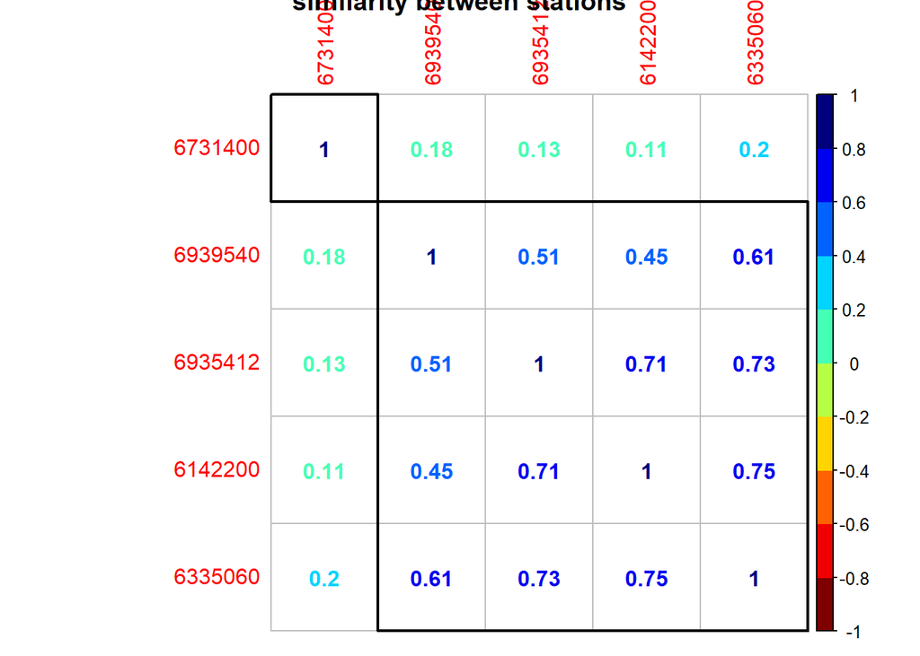

### 2.3.4 regreesion during summer and winter season of chosen stations

winter runoff is increasing as a function of time- espcially at river glama. In summer runnoff, runnoff is faling except for station luetschine

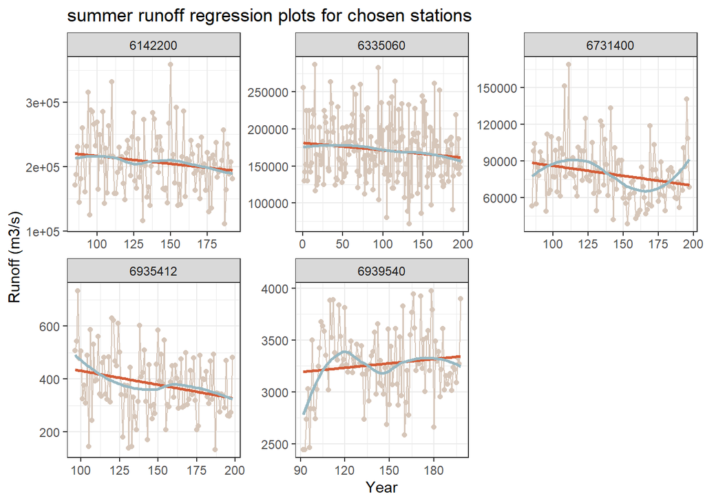

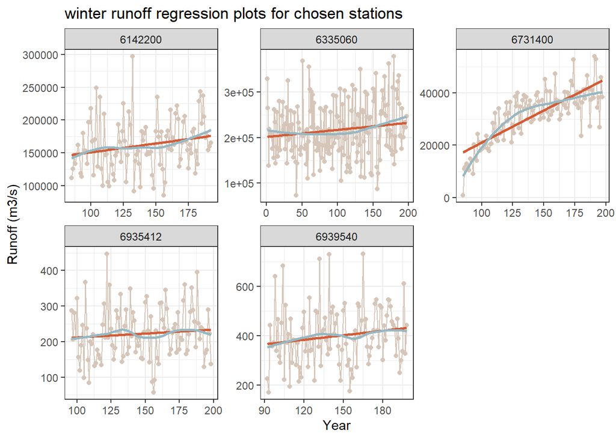

### 2.3.5 boxplot analysis

these plots also indicate a clear trend of increasing winter runnoff, while inconclusive evidence on summer runnoff

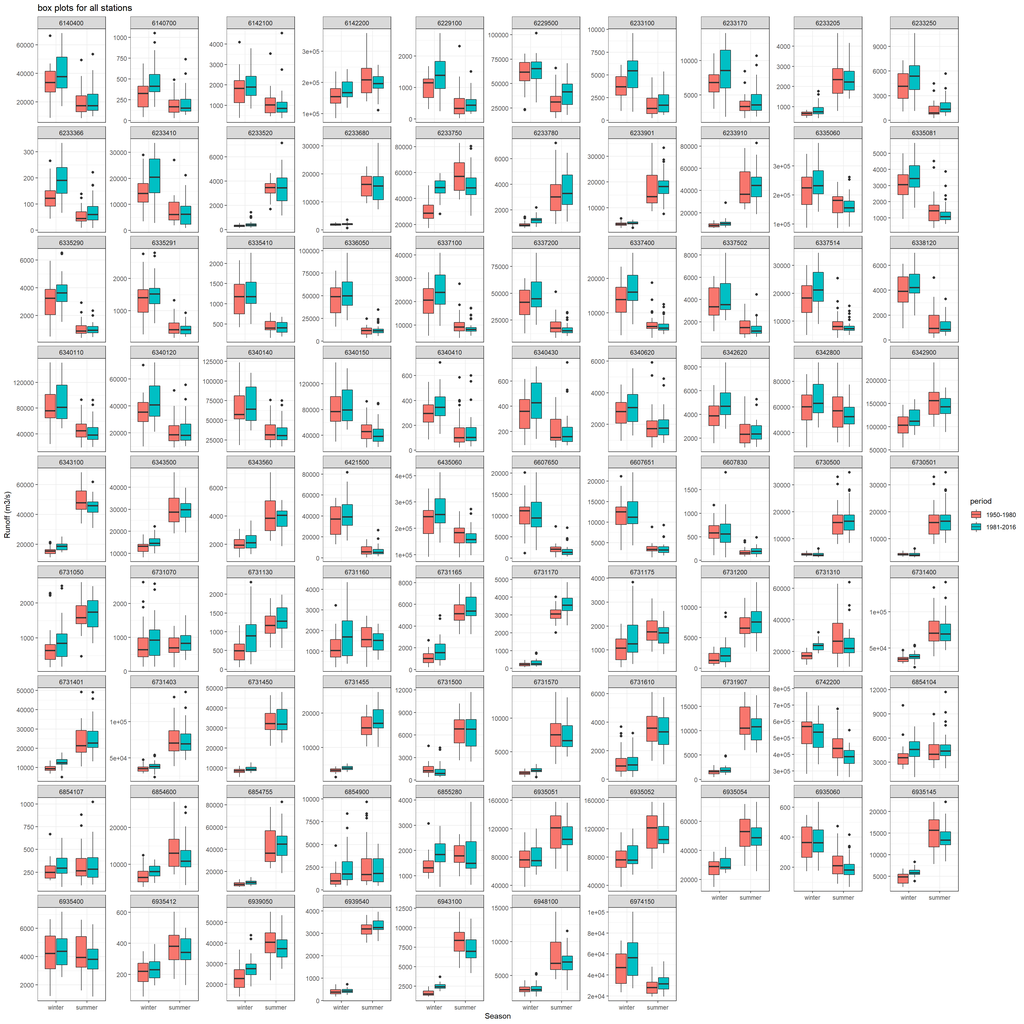

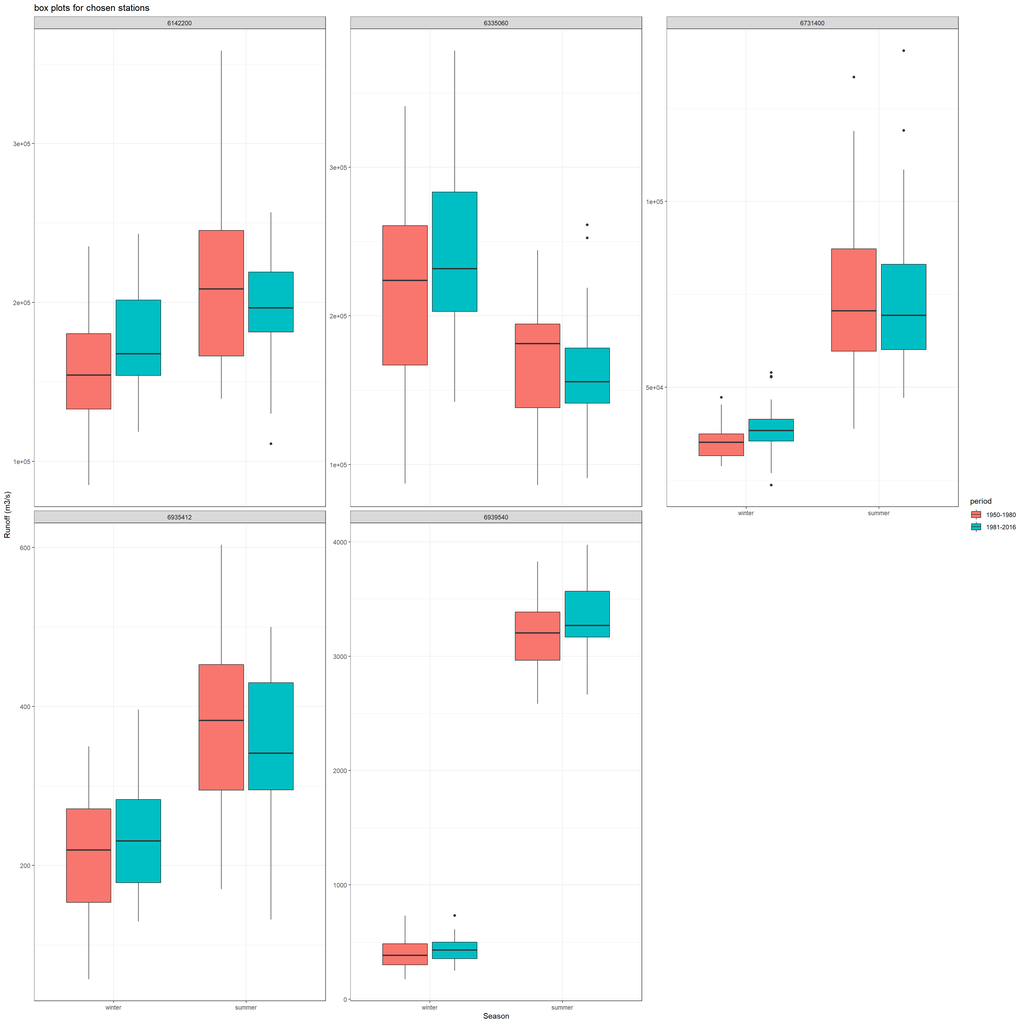

https://github.com/mr2214/project_EDA